# Text Mining with R

Mary Eng

2023-05-03

This overview is adapted from [*Text Mining with R: A Tidy Approach*](https://www.tidytextmining.com/index.html) by Julia Silge and David Robinson.

## 6: Topic modeling

We have been analyzing text documents that all share a theme or are in the same group. However, in text mining, we usually have larger collections of multiple unsorted documents. Topic modeling can be used to cluster documents into group in an unsupervised classification method.

A popular method for topic modeling is Latent Dirichlet Allocation (LDA). This method treats each document as a mixture of topics, and each topic as a mixture of words. Documents would have similar topics to other documents in an overlapping manner that more accurately reflects natural languages and not in discrete groups.

Adding topic modeling to our text analysis flowchart, we see topic modeling can be done on Document-Term Matrices to produce a model that can be used by tidytext and tidytools. We will be using the `topicmodels` package to illustrate examples.

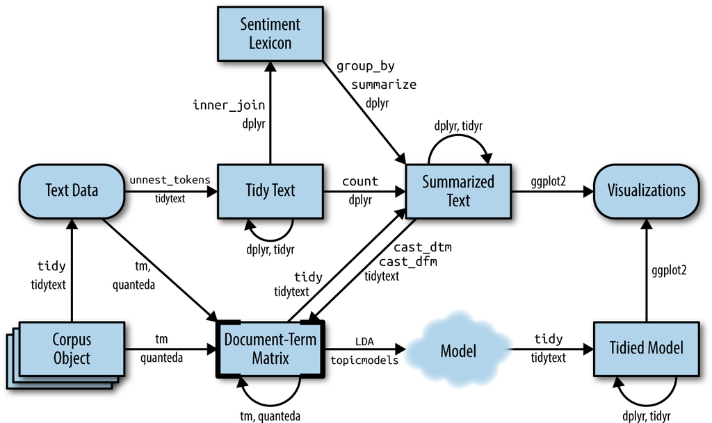

### Latent Dirichlet allocation (LDA)

LDA is one of the most common algorithms for topic modeling. We think of each document as a mixture of topics and each may have words from several topics of different proportions. In a two-topic model example, we could say “Document 1 is 90% topic A and 10% topic B, while Document 2 is 30% topic A and 70% topic B.” Every topic is considered a mixture of words. For example, the topic for “politics” may have common words such as “President”, “Congress”, and “government” and the topic for “entertainment” can be associated with words such as “movies”, “television”, and “actor.” However, both topics may contain an overlapping words like “budget” that might appear in both topics equally.

LDA is a mathematical method for estimating the mixture of words associated with a topic and which topics best describes a document. We can use the `LDA()` function from the topicmodels package and set k = 2 to create a two-topic LDA model. Most topic models in practice will use a larger k, but we will start with a simpler case. The output is an object containing model fit details, such as how words are associated with topics and how topics are associated with documents.

```r
library(topicmodels)
# collection of 2246 news articles from an American news agency, mostly published around 1988
data("AssociatedPress")
                             # k = num of topics, set seed so output is predictable
ap_lda <- LDA(AssociatedPress, k = 2, control = list(seed = 1234))
ap_lda
```

```
## A LDA_VEM topic model with 2 topics.
```

### Word-topic probabilities

The `tidytextt` package also provides a `tidy()` method for extracting per-topic-per-word probabilities ($\beta$) from the model in a tidy one item per row format.

```r
library(tidytext)

ap_topics <- tidy(ap_lda, matrix = "beta")
ap_topics
```

```
## # A tibble: 20,946 × 3
##    topic term           beta
##    <int> <chr>         <dbl>
##  1     1 aaron      1.69e-12
##  2     2 aaron      3.90e- 5
##  3     1 abandon    2.65e- 5
##  4     2 abandon    3.99e- 5
##  5     1 abandoned  1.39e- 4
##  6     2 abandoned  5.88e- 5
##  7     1 abandoning 2.45e-33
##  8     2 abandoning 2.34e- 5
##  9     1 abbott     2.13e- 6
## 10     2 abbott     2.97e- 5
## # ℹ 20,936 more rows
```

For each term in every topic, the $\beta$ value is the probability of that term being generated from that topic. To better visualize the 10 most common terms in each topic, we can input into ggplot2.

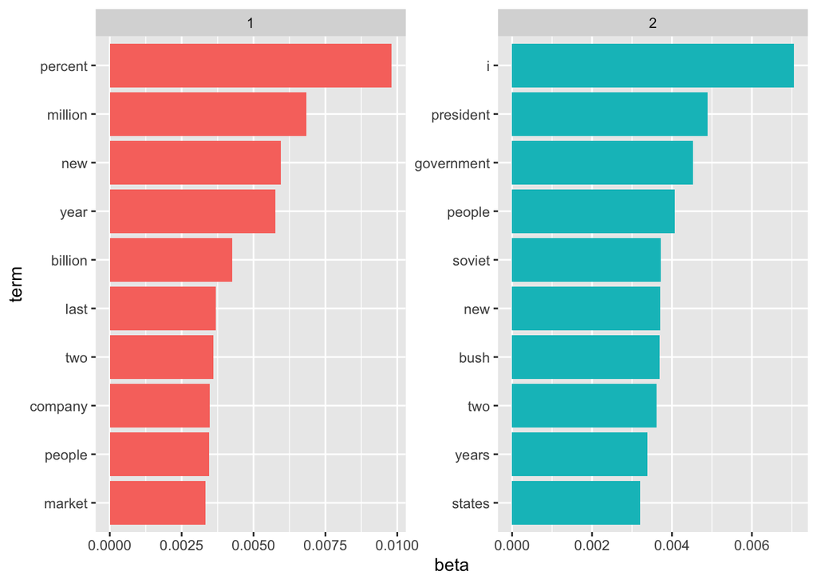

```r
library(ggplot2)
library(dplyr)
ap_top_terms <- ap_topics %>%
  group_by(topic) %>%
  slice_max(beta, n = 10) %>%
  ungroup() %>%
  arrange(topic, -beta)

ap_top_terms %>%
  mutate(term = reorder_within(term, beta, topic)) %>%
  ggplot(aes(beta, term, fill = factor(topic))) +
  geom_col(show.legend = FALSE) +
  facet_wrap(~ topic, scales = "free") +
  scale_y_reordered()
```

The most common words in topic 1 are “percent”, “million”, “billion”, and “company”, which suggests this topic may be relating to business or financial news. The most common terms in topic 2 include “president”, “government”, and “soviet”, suggesting that this topic represents political news. An important observation is that the same words may appear in multiple topics, such as “new” and “people.” This allows for more flexible and accurate clustering because terms don’t have to only indicate one topic.

As another approach, we could only consider the terms that had the greatest difference in beta between topic 1 and 2, which can be estimated based on the log ratio of the two $\beta$’s: $\log_2(\frac{\beta_2}{\beta_1})$. A log ratio is used because it makes the difference symmetrical: $\beta_2$ being twice as large leads to a log ratio of 1, while $\beta_1$ being twice as large results in -1.

```r
library(tidyr)

beta_wide <- ap_topics %>%
  mutate(topic = paste0("topic", topic)) %>%
  pivot_wider(names_from = topic, values_from = beta) %>%
  # filter for relatively common words with beta > .001
  filter(topic1 > .001 | topic2 > .001) %>%
  mutate(log_ratio = log2(topic2 / topic1))

beta_wide
```

```
## # A tibble: 198 × 4
##    term              topic1      topic2 log_ratio
##    <chr>              <dbl>       <dbl>     <dbl>
##  1 administration 0.000431  0.00138         1.68
##  2 ago            0.00107   0.000842       -0.339
##  3 agreement      0.000671  0.00104         0.630
##  4 aid            0.0000476 0.00105         4.46
##  5 air            0.00214   0.000297       -2.85
##  6 american       0.00203   0.00168        -0.270
##  7 analysts       0.00109   0.000000578   -10.9
##  8 area           0.00137   0.000231       -2.57
##  9 army           0.000262  0.00105         2.00
## 10 asked          0.000189  0.00156         3.05
## # ℹ 188 more rows
```

### Document-topic probabilities

LDA also models each document as a mixture of topics. We can examine the per-document-per-topics probabilities ($\gamma$) by setting the `matrix = 'gamma'` argument in `tidy()`. Each value is an estimated proportion of words from that documents that are generated from that topic. For document 1, about 25% of its words were generated from topic 1.

```r
ap_documents <- tidy(ap_lda, matrix = "gamma")
ap_documents
```

```
## # A tibble: 4,492 × 3
##    document topic    gamma
##       <int> <int>    <dbl>
##  1        1     1 0.248
##  2        2     1 0.362
##  3        3     1 0.527
##  4        4     1 0.357
##  5        5     1 0.181
##  6        6     1 0.000588
##  7        7     1 0.773
##  8        8     1 0.00445
##  9        9     1 0.967
## 10       10     1 0.147
## # ℹ 4,482 more rows
```

One interesting note we can see is that document 6 barely had any words from topic 1, so it is mostly generated from topic 2. We can take a closer look into the words that comprise the document.

```r
tidy(AssociatedPress) %>%
  filter(document == 6) %>%
  arrange(desc(count))
```

```
## # A tibble: 287 × 3
##    document term           count
##       <int> <chr>          <dbl>
##  1        6 noriega           16
##  2        6 panama            12
##  3        6 jackson            6
##  4        6 powell             6
##  5        6 administration     5
##  6        6 economic           5
##  7        6 general            5
##  8        6 i                  5
##  9        6 panamanian         5
## 10        6 american           4
## # ℹ 277 more rows
```

These words from document 6 look like they belong in the topic 2, which is about politics.

### Evaluation of Method

To evaluate how efficient topic modeling is, we can have an example where we know the true grouping of documents and see if the algorithm will assign them to the correct cluster. We have chapters of four known books and want to re-assign them to the titles they belong to. We first start making the dataset with chapters and tokenizing all the chapters of each book.

```r
titles <- c("Twenty Thousand Leagues under the Sea",
            "The War of the Worlds",
            "Pride and Prejudice",
            "Great Expectations")

library(gutenbergr)
library(stringr)

books <- gutenberg_works(title %in% titles) %>%
  gutenberg_download(meta_fields = "title")
```

```
## Determining mirror for Project Gutenberg from https://www.gutenberg.org/robot/harvest
```

```
## `curl` package not installed, falling back to using `url()`
## Using mirror http://aleph.gutenberg.org
```

```r
# divide into documents, each representing one chapter
by_chapter <- books %>%
  group_by(title) %>%
  mutate(chapter = cumsum(str_detect(
    text, regex("chapter ", ignore_case = TRUE)
  ))) %>%
  ungroup() %>%
  filter(chapter > 0) %>%
  unite(document, title, chapter)

# split into words
by_chapter_word <- by_chapter %>%
  unnest_tokens(word, text)

# find document-word counts
word_counts <- by_chapter_word %>%
  anti_join(stop_words) %>%
  count(document, word, sort = TRUE)
word_counts
```

```
## # A tibble: 95,687 × 3
##    document                word         n
##    <chr>                   <chr>    <int>
##  1 Great Expectations_119  joe         88
##  2 The War of the Worlds_1 martians    82
##  3 Great Expectations_66   joe         70
##  4 Great Expectations_76   biddy       63
##  5 The War of the Worlds_1 time        61
##  6 Great Expectations_86   joe         58
##  7 Great Expectations_98   estella     57
##  8 Great Expectations_61   joe         56
##  9 Great Expectations_82   pocket      53
## 10 The War of the Worlds_1 black       53
## # ℹ 95,677 more rows
```

Now that we have a tidy data frame, we need to convert it to a Document Term Matrix in order to be inputted into the `topicmodels` package.

```r
chapters_dtm <- word_counts %>%
  cast_dtm(document, word, n)

chapters_dtm
```

```
## <<DocumentTermMatrix (documents: 303, terms: 17568)>>
## Non-/sparse entries: 95687/5227417
## Sparsity           : 98%
## Maximal term length: 19
## Weighting          : term frequency (tf)
```

Next, we create a four-topic model with k=4 with LDA because there are 4 books.

```r
chapters_lda <- LDA(chapters_dtm, k = 4, control = list(seed = 1234))
chapters_lda
```

```
## A LDA_VEM topic model with 4 topics.
```

Then we can use `tidy()` to see the per-topic-per-word probabilities, of that term being generated from that topic in each row.

```r
chapter_topics <- tidy(chapters_lda, matrix = "beta")
chapter_topics
```

```
## # A tibble: 70,272 × 3
##    topic term          beta
##    <int> <chr>        <dbl>
##  1     1 joe      1.54e-  2
##  2     2 joe      6.01e- 19
##  3     3 joe      1.91e- 76
##  4     4 joe      7.40e-  3
##  5     1 martians 3.31e-  3
##  6     2 martians 7.17e-123
##  7     3 martians 2.94e- 69
##  8     4 martians 3.59e-115
##  9     1 biddy    7.47e-  3
## 10     2 biddy    2.75e- 23
## # ℹ 70,262 more rows
```

Finding the top 5 terms within each topic:

```r
top_terms <- chapter_topics %>%
  group_by(topic) %>%
  slice_max(beta, n = 5) %>%
  ungroup() %>%
  arrange(topic, -beta)

top_terms
```

```
## # A tibble: 20 × 3
##    topic term           beta
##    <int> <chr>         <dbl>
##  1     1 joe         0.0154
##  2     1 biddy       0.00747
##  3     1 time        0.00579
##  4     1 pip         0.00480
##  5     1 pumblechook 0.00470
##  6     2 elizabeth   0.0155
##  7     2 darcy       0.00973
##  8     2 bennet      0.00781
##  9     2 miss        0.00762
## 10     2 jane        0.00724
## 11     3 captain     0.0152
## 12     3 _nautilus_  0.0126
## 13     3 sea         0.00880
## 14     3 nemo        0.00867
## 15     3 ned         0.00796
## 16     4 joe         0.00740
## 17     4 time        0.00685
## 18     4 looked      0.00668
## 19     4 herbert     0.00647
## 20     4 miss        0.00624
```

Plotting the terms that are most common within each topic, we get:

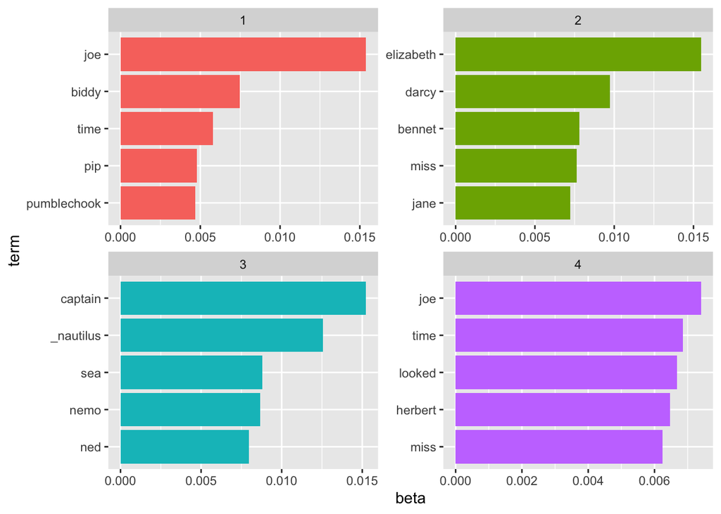

```r
library(ggplot2)

top_terms %>%
  mutate(term = reorder_within(term, beta, topic)) %>%
  ggplot(aes(beta, term, fill = factor(topic))) +
  geom_col(show.legend = FALSE) +
  facet_wrap(~ topic, scales = "free") +
  scale_y_reordered()
```

What if we wanted to know which topics are associated with each document and put the chapters back together in their correct books? We can do this by examining the per-document-per-topic probabilities ($\gamma$), the estimated proportion of words from that document that are generated from that topic. For example, the model estimates that each word in Great Expectations_57 has 4% probability of being from topic 1.

```r
chapters_gamma <- tidy(chapters_lda, matrix = "gamma")
chapters_gamma
```

```
## # A tibble: 1,212 × 3
##    document                topic     gamma
##    <chr>                   <int>     <dbl>
##  1 Great Expectations_119      1 0.805
##  2 The War of the Worlds_1     1 1.00
##  3 Great Expectations_66       1 1.00
##  4 Great Expectations_76       1 0.724
##  5 Great Expectations_86       1 0.0000318
##  6 Great Expectations_98       1 0.297
##  7 Great Expectations_61       1 0.0000280
##  8 Great Expectations_82       1 0.0000309
##  9 Great Expectations_74       1 0.804
## 10 Great Expectations_77       1 0.0000210
## # ℹ 1,202 more rows
```

Having these topic probabilities, we can see how well the unsupervised clustering did at distinguishing the four books. We would expect that chapters within a book would be found to be mostly (or entirely), generated from the corresponding topic. We re-separate the document name into title and chapter, then visualize the per-document-per-topic probability for each.

```r
chapters_gamma <- chapters_gamma %>%
  separate(document, c("title", "chapter"), sep = "_", convert = TRUE)

chapters_gamma
```

```
## # A tibble: 1,212 × 4
##    title                 chapter topic     gamma
##    <chr>                   <int> <int>     <dbl>
##  1 Great Expectations        119     1 0.805
##  2 The War of the Worlds       1     1 1.00
##  3 Great Expectations         66     1 1.00
##  4 Great Expectations         76     1 0.724
##  5 Great Expectations         86     1 0.0000318
##  6 Great Expectations         98     1 0.297
##  7 Great Expectations         61     1 0.0000280
##  8 Great Expectations         82     1 0.0000309
##  9 Great Expectations         74     1 0.804
## 10 Great Expectations         77     1 0.0000210
## # ℹ 1,202 more rows
```

The gamma probabilities for each chapter within each book:

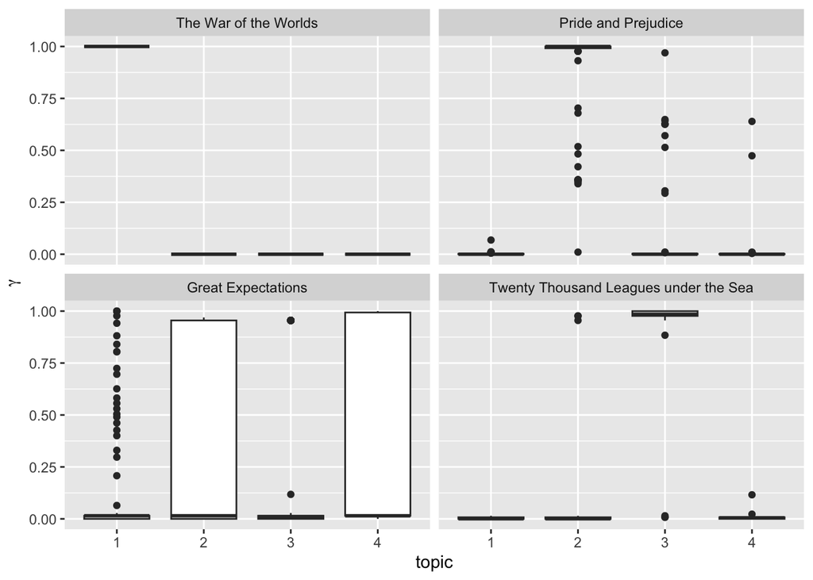

```r
chapters_gamma %>%
  mutate(title = reorder(title, gamma * topic)) %>%
  ggplot(aes(factor(topic), gamma)) +
  geom_boxplot() +
  facet_wrap(~ title) +
  labs(x = "topic", y = expression(gamma))
```

```r
chapter_classifications <- chapters_gamma %>%
  group_by(title, chapter) %>%
  slice_max(gamma) %>%
  ungroup()

chapter_classifications
```

```
## # A tibble: 303 × 4
##    title              chapter topic gamma
##    <chr>                <int> <int> <dbl>
##  1 Great Expectations       1     2 0.915
##  2 Great Expectations       2     3 0.955
##  3 Great Expectations       3     3 0.955
##  4 Great Expectations       4     3 0.955
##  5 Great Expectations       5     2 0.915
##  6 Great Expectations       6     3 0.955
##  7 Great Expectations       7     3 0.955
##  8 Great Expectations       8     3 0.955
##  9 Great Expectations       9     3 0.955
## 10 Great Expectations      10     2 0.915
## # ℹ 293 more rows
```

We can then compare each to the most common topic among its chapters), and see which were most often misidentified.

```r
book_topics <- chapter_classifications %>%
  count(title, topic) %>%
  group_by(title) %>%
  slice_max(n, n = 1) %>%
  ungroup() %>%
  transmute(consensus = title, topic)

chapter_classifications %>%
  inner_join(book_topics, by = "topic") %>%
  filter(title != consensus)
```

```
## # A tibble: 90 × 5
##    title              chapter topic gamma consensus
##    <chr>                <int> <int> <dbl> <chr>
##  1 Great Expectations       1     2 0.915 Pride and Prejudice
##  2 Great Expectations       2     3 0.955 Twenty Thousand Leagues under the Sea
##  3 Great Expectations       3     3 0.955 Twenty Thousand Leagues under the Sea
##  4 Great Expectations       4     3 0.955 Twenty Thousand Leagues under the Sea
##  5 Great Expectations       5     2 0.915 Pride and Prejudice
##  6 Great Expectations       6     3 0.955 Twenty Thousand Leagues under the Sea
##  7 Great Expectations       7     3 0.955 Twenty Thousand Leagues under the Sea
##  8 Great Expectations       8     3 0.955 Twenty Thousand Leagues under the Sea
##  9 Great Expectations       9     3 0.955 Twenty Thousand Leagues under the Sea
## 10 Great Expectations      10     2 0.915 Pride and Prejudice
## # ℹ 80 more rows
```

There is some misclassification for *Great Expectations*, but overall chapters were classified correctly.

### Word Assignments

One step of the LDA algorithm is assigning each word in each document to a topic. The more words in a document that are assigned to that topic, the more weight ($\gamma$) will usually go on that document-topic classification.

We could take the original document-word pairs and find which words in each document were assigned to which topic. The `augment()` function from the `broom` package is a way of tidying model output. While `tidy()` retrieves the statistical components of the model, `augment()` uses the model to add information to each observation in the original data. The output of the function is a tidy data frame of book-term counts with an extra column `.topic`, where the topic each term was assigned to within each document. The `.` notation is default to prevent overwriting existing columns.

```r
assignments <- augment(chapters_lda, data = chapters_dtm)
assignments
```

```
## # A tibble: 95,687 × 4
##    document               term  count .topic
##    <chr>                  <chr> <dbl>  <dbl>
##  1 Great Expectations_119 joe      88      1
##  2 Great Expectations_66  joe      70      1
##  3 Great Expectations_76  joe       5      1
##  4 Great Expectations_86  joe      58      4
##  5 Great Expectations_61  joe      56      4
##  6 Great Expectations_82  joe       1      4
##  7 Great Expectations_74  joe      50      1
##  8 Great Expectations_77  joe      50      4
##  9 Great Expectations_68  joe      44      1
## 10 Great Expectations_72  joe      40      1
## # ℹ 95,677 more rows
```

We could combine the assignments table with the consensus book titles to find which words were incorrectly classified.

```r
assignments <- assignments %>%
  separate(document, c("title", "chapter"),
           sep = "_", convert = TRUE) %>%
  inner_join(book_topics, by = c(".topic" = "topic"))

assignments
```

```
## # A tibble: 95,687 × 6
##    title              chapter term  count .topic consensus
##    <chr>                <int> <chr> <dbl>  <dbl> <chr>
##  1 Great Expectations     119 joe      88      1 The War of the Worlds
##  2 Great Expectations      66 joe      70      1 The War of the Worlds
##  3 Great Expectations      76 joe       5      1 The War of the Worlds
##  4 Great Expectations      86 joe      58      4 Great Expectations
##  5 Great Expectations      61 joe      56      4 Great Expectations
##  6 Great Expectations      82 joe       1      4 Great Expectations
##  7 Great Expectations      74 joe      50      1 The War of the Worlds
##  8 Great Expectations      77 joe      50      4 Great Expectations
##  9 Great Expectations      68 joe      44      1 The War of the Worlds
## 10 Great Expectations      72 joe      40      1 The War of the Worlds
## # ℹ 95,677 more rows
```

Having the true label and the predicted label is using for further analysis, such as visualizing a confusion matrix to show how often words from one book were assigned to another.

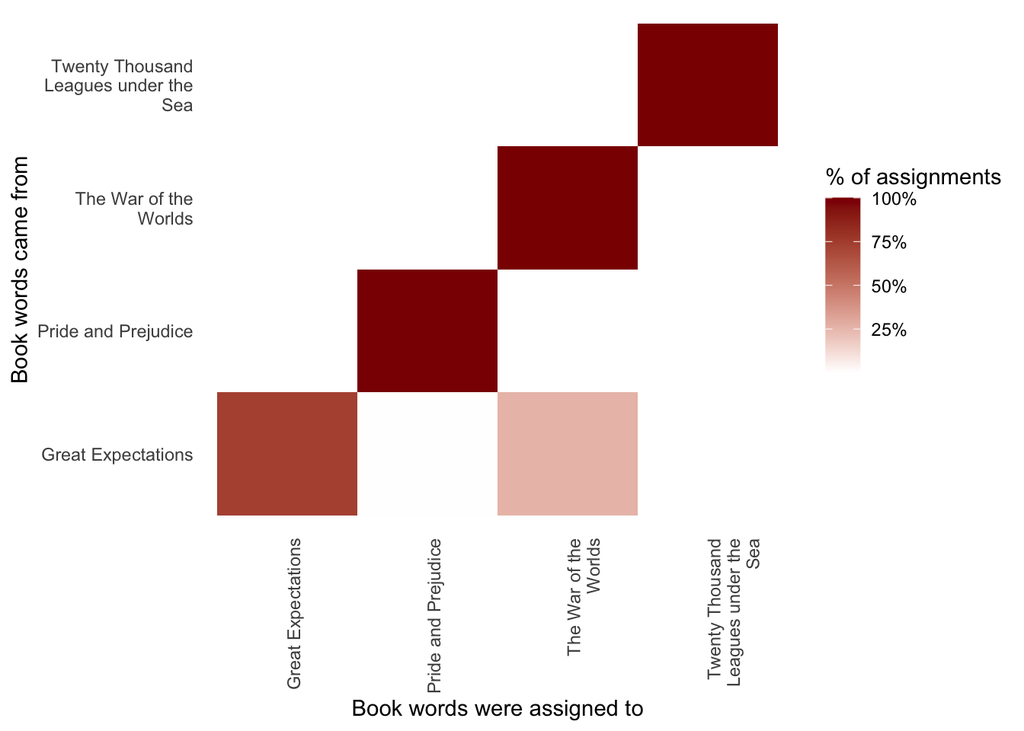

```r
library(scales)

assignments %>%
  count(title, consensus, wt = count) %>%
  mutate(across(c(title, consensus), ~str_wrap(., 20))) %>%
  group_by(title) %>%
  mutate(percent = n / sum(n)) %>%
  ggplot(aes(consensus, title, fill = percent)) +
  geom_tile() +
  scale_fill_gradient2(high = "darkred", label = percent_format()) +
  theme_minimal() +
  theme(axis.text.x = element_text(angle = 90, hjust = 1),
        panel.grid = element_blank()) +
  labs(x = "Book words were assigned to",
       y = "Book words came from",
       fill = "% of assignments")
```

```r
wrong_words <- assignments %>%
  filter(title != consensus)

wrong_words %>%
  count(title, consensus, term, wt = count) %>%
  ungroup() %>%
  arrange(desc(n))
```

```
## # A tibble: 5,283 × 4
##    title              consensus             term            n
##    <chr>              <chr>                 <chr>       <dbl>
##  1 Great Expectations The War of the Worlds joe           425
##  2 Great Expectations The War of the Worlds biddy         191
##  3 Great Expectations The War of the Worlds pip           126
##  4 Great Expectations The War of the Worlds pumblechook   122
##  5 Great Expectations The War of the Worlds sister        108
##  6 Great Expectations The War of the Worlds miss           90
##  7 Great Expectations The War of the Worlds don’t          73
##  8 Great Expectations The War of the Worlds time           73
##  9 Great Expectations The War of the Worlds house          72
## 10 Great Expectations The War of the Worlds day            65
## # ℹ 5,273 more rows
```

We see a lot of words assigned to *The War of the Worlds* even when they appeared in *Great Expectations* because there are overlapping words between the two books. The LDA algorithm is stochastic, meaning it uses randomness to find the optima of an objective function, and it can accidentally land on a topic that spans multiple books.

In summary, we see how unsupervised clustering methods like topic modelings are useful for grouping documents in a more realistic manner.